# Behind the Paycheck: Salary Patterns in DC Public Employment

This project analyzes the DC Public Employee Salary dataset, which contains salary and employment information for public employees in Washington, DC. The dataset includes details such as employee job title, agency or department description, grade, compensation rate, hire date, appointment type, and object ID.

This dataset is analytically interesting because public salary data can reveal patterns in government employment, compensation differences across agencies, and the types of positions associated with higher compensation rates. By studying these patterns, this project explores how employee role, agency, grade, appointment type, and hire date may relate to compensation rate differences in DC public employment.

## Objective and Research Question

The objective of this project is to examine compensation patterns among Washington, DC public employees and identify which factors appear to be most associated with higher compensation rates. The main research question is:

**Which features appear to be most strongly associated with higher public employee compensation in Washington, DC?**

Additional research questions:

1. Which agencies have the highest average compensation?
2. Which job titles are associated with the highest compensation?
3. How is compensation distributed across DC public employees?
4. Does employee grade appear to relate to compensation?
5. Are there noticeable outliers or unusually high compensations in the dataset?
6. Does hire date or length of service reveal any compensation patterns?

```python
#importing libraries
import pandas as pd
import numpy as np
import matplotlib.pyplot as plt
import seaborn as sns
import plotly.express as px
```

```python
#loads in the dataset
df = pd.read_csv("DC_Public_Employee_Salary.csv")
```

```python
#displays the first five rows
df.head()
```

|  | FIRST_NAME | LAST_NAME | JOBTITLE | DESCRSHORT | GRADE | COMPRATE | HIREDATE_STRING | GVT_TYPE_OF_APPT | OBJECTID |
| --- | --- | --- | --- | --- | --- | --- | --- | --- | --- |
| 0 | Natasha | Boley | Compliance Specialist | DBH | 13 | 123873.00 | 2004/10/18 | CS - Reg | 1 |
| 1 | Korlu | Wolobah-Kuyon | PSYCHIATRIC NURSE | DBH | 09 | 115907.00 | 2020/08/17 | CS - Reg | 2 |
| 2 | Hadizat | Elayo-Ross | SUPERVISORY PSYCHIATRIC NURSE | DBH | 13 | 122500.00 | 2023/08/14 | MSS - Reg | 3 |
| 3 | Gary | Evans | Climate Control Maint Mechanic | DBH | 11 | 41.73 | 1985/08/27 | CS - Reg | 4 |
| 4 | Jemia | Gross | Special Police Officer | DBH | 08 | 75787.00 | 2016/11/14 | CS - Reg | 5 |

```python
#displays the last five rows
df.tail()
```

|  | FIRST_NAME | LAST_NAME | JOBTITLE | DESCRSHORT | GRADE | COMPRATE | HIREDATE_STRING | GVT_TYPE_OF_APPT | OBJECTID |
| --- | --- | --- | --- | --- | --- | --- | --- | --- | --- |
| 40606 | Zaid | Coleman | ADJUNCT INSTRUCTOR - WDLL | UDC | 01 | 0.03 | 2023/01/03 | Ed - Temp | 40607 |
| 40607 | Pablo | Larreategui Plaza | Adjunct Professor-SEIU | UDC | 01 | 210.00 | 2025/05/16 | Ed - Temp | 40608 |
| 40608 | Myron | Douglas | ASST PROFESSOR | UDC | 04 | 83843.46 | 2008/06/01 | Ed - Reg | 40609 |
| 40609 | Yoko | Ferguson | ASSOCIATE PROFESSOR | UDC | 03 | 91965.50 | 2022/08/16 | Ed - Reg | 40610 |
| 40610 | Spiros | Giannaros | ASST PROFESSOR | UDC | 04 | 82465.00 | 2023/08/16 | Ed - Reg | 40611 |

```python
#prints out the shape of the dataset
print("Shape of dataset:", df.shape)
```

```
Shape of dataset: (40611, 9)
```

```python
#prints out the column names
print(df.columns)
```

```
Index(['FIRST_NAME', 'LAST_NAME', 'JOBTITLE', 'DESCRSHORT', 'GRADE',
       'COMPRATE', 'HIREDATE_STRING', 'GVT_TYPE_OF_APPT', 'OBJECTID'],
      dtype='object')
```

```python
#displays the data types and non-null counts
df.info()
```

```
<class 'pandas.core.frame.DataFrame'>
RangeIndex: 40611 entries, 0 to 40610
Data columns (total 9 columns):
 #   Column            Non-Null Count  Dtype
---  ------            --------------  -----
 0   FIRST_NAME        40611 non-null  object
 1   LAST_NAME         40611 non-null  object
 2   JOBTITLE          40611 non-null  object
 3   DESCRSHORT        40611 non-null  object
 4   GRADE             40571 non-null  object
 5   COMPRATE          40611 non-null  float64
 6   HIREDATE_STRING   40611 non-null  object
 7   GVT_TYPE_OF_APPT  40611 non-null  object
 8   OBJECTID          40611 non-null  int64
dtypes: float64(1), int64(1), object(7)
memory usage: 2.8+ MB
```

```python
#summary statistics for the numerical columns
df.describe()
```

|  | COMPRATE | OBJECTID |
| --- | --- | --- |
| count | 40611.000000 | 40611.000000 |
| mean | 89087.755572 | 20306.000000 |
| std | 47453.788915 | 11723.530228 |
| min | 0.030000 | 1.000000 |
| 25% | 66130.000000 | 10153.500000 |
| 50% | 93234.000000 | 20306.000000 |
| 75% | 119643.130000 | 30458.500000 |
| max | 390232.000000 | 40611.000000 |

```python
#summary statistics for all the columns
df.describe(include="all")
```

|  | FIRST_NAME | LAST_NAME | JOBTITLE | DESCRSHORT | GRADE | COMPRATE | HIREDATE_STRING | GVT_TYPE_OF_APPT | OBJECTID |
| --- | --- | --- | --- | --- | --- | --- | --- | --- | --- |
| count | 40611 | 40611 | 40611 | 40611 | 40571 | 40611.000000 | 40611 | 40611 | 40611.000000 |
| unique | 12930 | 15110 | 3698 | 88 | 68 | NaN | 4914 | 18 | NaN |
| top | Michael | Williams | OFFICER | DCPS | 15 | NaN | 2025/08/11 | CS - Reg | NaN |
| freq | 466 | 588 | 2027 | 11764 | 7376 | NaN | 402 | 19794 | NaN |
| mean | NaN | NaN | NaN | NaN | NaN | 89087.755572 | NaN | NaN | 20306.000000 |
| std | NaN | NaN | NaN | NaN | NaN | 47453.788915 | NaN | NaN | 11723.530228 |
| min | NaN | NaN | NaN | NaN | NaN | 0.030000 | NaN | NaN | 1.000000 |
| 25% | NaN | NaN | NaN | NaN | NaN | 66130.000000 | NaN | NaN | 10153.500000 |
| 50% | NaN | NaN | NaN | NaN | NaN | 93234.000000 | NaN | NaN | 20306.000000 |
| 75% | NaN | NaN | NaN | NaN | NaN | 119643.130000 | NaN | NaN | 30458.500000 |
| max | NaN | NaN | NaN | NaN | NaN | 390232.000000 | NaN | NaN | 40611.000000 |

The initial data understanding stage shows the structure of the dataset, including the number of rows and columns, the column names, the different data types, the missing values, and the summary statistics. This step helps identify which variables are useful for compensation rate analysis and which columns may need to be cleaned before visualizing them.

```python
#checks for missing values in each column
df.isnull().sum()
```

```
FIRST_NAME           0
LAST_NAME            0
JOBTITLE             0
DESCRSHORT           0
GRADE               40
COMPRATE             0
HIREDATE_STRING      0
GVT_TYPE_OF_APPT     0
OBJECTID             0
dtype: int64
```

```python
#checks for duplicate rows
df.duplicated().sum()
```

```
np.int64(0)
```

## Data Understanding and Cleaning

```python
#creates a copy of the original dataset
df_clean = df.copy()
```

```python
#standardizes the column names — strip, lowercase, then rename to readable names
df_clean.columns = df_clean.columns.str.strip().str.lower()
df_clean = df_clean.rename(columns={"jobtitle": "job_title", "descrshort": "agency","hiredate_string": "hire_date","gvt_type_of_appt": "appointment_type"})

#drops columns irrelevant to comprate analysis
df_clean = df_clean.drop(columns=["first_name", "last_name", "objectid"])
print("Columns after rename and drop:", df_clean.columns.tolist())
```

```
Columns after rename and drop: ['job_title', 'agency', 'grade', 'comprate', 'hire_date', 'appointment_type']
```

```python
#standardizes job title capitalization
df_clean["job_title"] = df_clean["job_title"].str.title()
```

```python
#fills the missing grade values with "Unknown"
df_clean["grade"] = df_clean["grade"].fillna("Unknown")
```

The grade column had 40 missing values. Since grade is a categorical variable, I filled the missing values with "Unknown" instead of deleting the rows or using a numerical replacement. This allowed me to keep the employee records while still making the missing grade values clear during analysis.

```python
#removes the duplicate rows
df_clean = df_clean.drop_duplicates()
```

```python
#removes extra spaces from text columns
df_clean = df_clean.apply(lambda col: col.str.strip() if col.dtype == "object" else col)
```

```python
#converts the hire date into datetime format
df_clean["hire_date"] = pd.to_datetime(df_clean["hire_date"], errors="coerce")
```

```python
print(df_clean.columns.tolist())
```

```
['job_title', 'agency', 'grade', 'comprate', 'hire_date', 'appointment_type']
```

```python
#displays the cleaned data
df_clean.head()
```

|  | job_title | agency | grade | comprate | hire_date | appointment_type |
| --- | --- | --- | --- | --- | --- | --- |
| 0 | Compliance Specialist | DBH | 13 | 123873.00 | 2004-10-18 | CS - Reg |
| 1 | Psychiatric Nurse | DBH | 09 | 115907.00 | 2020-08-17 | CS - Reg |
| 2 | Supervisory Psychiatric Nurse | DBH | 13 | 122500.00 | 2023-08-14 | MSS - Reg |
| 3 | Climate Control Maint Mechanic | DBH | 11 | 41.73 | 1985-08-27 | CS - Reg |
| 4 | Special Police Officer | DBH | 08 | 75787.00 | 2016-11-14 | CS - Reg |

```python
#checks the cleaned dataset information
df_clean.info()
```

```
<class 'pandas.core.frame.DataFrame'>
Index: 33563 entries, 0 to 40609
Data columns (total 6 columns):
 #   Column            Non-Null Count  Dtype
---  ------            --------------  -----
 0   job_title         33563 non-null  object
 1   agency            33563 non-null  object
 2   grade             33563 non-null  object
 3   comprate          33563 non-null  float64
 4   hire_date         33563 non-null  datetime64[ns]
 5   appointment_type  33563 non-null  object
dtypes: datetime64[ns](1), float64(1), object(4)
memory usage: 1.8+ MB
```

```python
#checks for missing values after cleaning
df_clean.isnull().sum()
```

```
job_title           0
agency              0
grade               0
comprate            0
hire_date           0
appointment_type    0
dtype: int64
```

```python
#checks the shape after cleaning
print("Original shape:", df.shape)
print("Cleaned shape:", df_clean.shape)
```

```
Original shape: (40611, 9)
Cleaned shape: (33563, 6)
```

I created a cleaned copy of the original dataset so the raw data would remain unchanged. I standardized the column names, removed duplicate rows, removed the extra spaces from text fields, renamed columns for easier understanding, and converted the hire date column into a datetime format. These steps make the dataset easier to analyze and reduce errors when grouping, filtering, and visualizing the data.

## Exploratory Data Analysis

This section explores the dataset before creating the main visualizations. The goal is to understand compensation rate ranges, common job titles, agency representation, and the group-level compensation rate patterns.

```python
#comp rate summary statistics
df_clean["comprate"].describe()
```

```
count     33563.000000
mean      91381.820199
std       47828.010448
min           0.030000
25%       67383.000000
50%       95700.000000
75%      120569.000000
max      390232.000000
Name: comprate, dtype: float64
```

```python
#lists the most common agencies
df_clean["agency"].value_counts().head(10)
```

```
agency
DCPS        9841
MPD         2405
UDC         1527
OCFO        1378
DBH         1164
DPW         1131
DDOT        1117
DHS         1084
FEMS        1060
OSSE DOT     824
Name: count, dtype: int64
```

```python
#lists the most common job titles
df_clean["job_title"].value_counts().head(10)
```

```
job_title
Teacher, General Elementary    912
Teacher, Special Ed.           755
Program Analyst                721
Officer                        643
Motor Vehicle Operator         597
Teacher, General Secondary     584
Substitute Teacher             522
Aide, 10Mo Special Ed          471
Social Worker                  448
Adjunct Professor-Seiu         384
Name: count, dtype: int64
```

```python
#average comp rate by agency
df_clean.groupby("agency")["comprate"].mean().sort_values(ascending=False).head(10)
```

```
agency
CJDT    187500.000000
MOLC    163643.803000
OSA     153089.606000
OEA     151215.122500
CAB     146127.447273
DCA     142048.751852
PSC     139088.642000
RHC     138841.731429
OCA     137245.592909
OAG     129048.369623
Name: comprate, dtype: float64
```

```python
#average comp rate by job title
df_clean.groupby("job_title")["comprate"].mean().sort_values(ascending=False).head(10)
```

```
job_title
Medical Officer (Psychiatry)      350616.181429
Medical Officer Psychiatry        340721.737500
Medical Officer Neurology         322505.000000
Chief Medical Examiner            320901.590000
President                         310000.000000
Medical Officer (Medical Exami    307347.200000
City Administrator                305100.000000
Chief Academic Officer            296506.880000
Supv Medical Officer (Psychiat    288474.770000
Executive Assistant Chief Of P    281136.000000
Name: comprate, dtype: float64
```

```python
#average comprate by appointment type
df_clean.groupby("appointment_type")["comprate"].mean().sort_values(ascending=False)
```

```
appointment_type
Exe - Reg     211817.718197
LS - Reg      159471.621928
Exe - Term    138187.536000
MSS - Temp    134044.482500
ExS - Reg     130090.021942
LS - Term     128210.470588
MSS - Reg     126736.241030
ExS - Term    124087.834211
Exe - Temp    114867.666667
Acting        102457.111111
CS - Reg       94107.281029
MSS - Term     91778.741538
Ed - Reg       86614.605162
CS - Term      79378.705357
Ed - Term      71697.482097
ExS - Temp     49796.822500
CS - Temp      29313.831070
Ed - Temp       9591.549284
Name: comprate, dtype: float64
```

```python
#creates a year hired column for time-based analysis
df_clean["hire_year"] = df_clean["hire_date"].dt.year
```

```python
#averages the comprate by hire year
df_clean.groupby("hire_year")["comprate"].mean().dropna().tail(20)
```

```
hire_year
2006     98715.382607
2007    104245.128265
2008    103450.964481
2009     99781.687837
2010    101104.598584
2011    102228.759636
2012    104146.468708
2013    103191.007101
2014     99313.115168
2015    100034.598978
2016     96708.626513
2017     93009.574763
2018     89496.944793
2019     89634.820512
2020     92475.455477
2021     86404.144432
2022     83298.493545
2023     76491.495033
2024     72254.757128
2025     69671.679949
Name: comprate, dtype: float64
```

## Data Visualization and Interpretation

### Visualization 1: Distribution of Compensation Rates

Intent: This visualization shows how compensation rates are distributed across DC public employees.

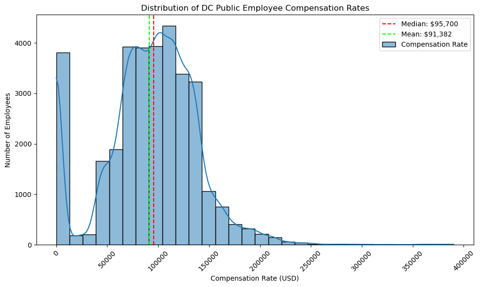

```python
plt.figure(figsize=(10, 6))
ax = sns.histplot(data=df_clean, x="comprate", bins=30, kde=True, label="Compensation Rate")
plt.title("Distribution of DC Public Employee Compensation Rates")
plt.xlabel("Compensation Rate (USD)")
plt.ylabel("Number of Employees")
plt.xticks(rotation=45)
plt.axvline(df_clean["comprate"].median(), color="red", linestyle="--", label=f'Median: ${df_clean["comprate"].median():,.0f}')
plt.axvline(df_clean["comprate"].mean(), color="lime", linestyle="--", label=f'Mean: ${df_clean["comprate"].mean():,.0f}')
plt.legend()
plt.tight_layout()
plt.show()
```

This graph shows the overall spread of compensation rates in the dataset. If the distribution is right-skewed, that means most employees earn within a lower-to-middle range while a smaller number of employees have much higher compensation rates.

### Visualization 2: Top Agencies by Number of Employees

Intent: This visualization identifies which agencies appear most often in the dataset.

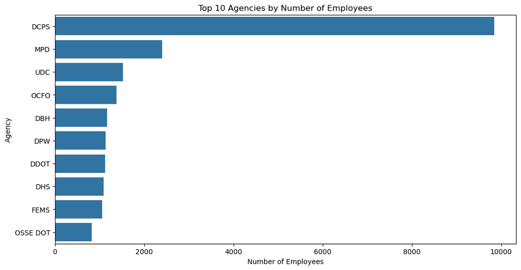

```python
top_agency_counts = df_clean["agency"].value_counts().head(10)
plt.figure(figsize=(12, 6))
sns.barplot(x=top_agency_counts.values, y=top_agency_counts.index)
plt.title("Top 10 Agencies by Number of Employees")
plt.xlabel("Number of Employees")
plt.ylabel("Agency")
plt.show()
```

This chart shows which agencies have the largest number of employee records. This matters because larger agencies may have more influence on the overall compensation rate distribution.

### Visualization 3: Top Agencies by Average Compensation Rate

Intent: This visualization compares agencies based on average compensation rate.

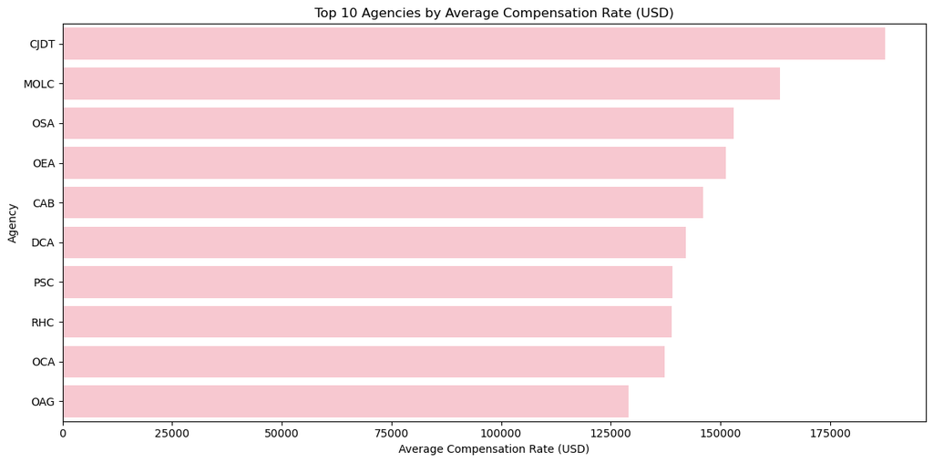

```python
top_agency_comprate = df_clean.groupby("agency")["comprate"].mean().sort_values(ascending=False).head(10)
plt.figure(figsize=(12, 6))
sns.barplot(x=top_agency_comprate.values, y=top_agency_comprate.index, color="pink")
plt.title("Top 10 Agencies by Average Compensation Rate (USD)")
plt.xlabel("Average Compensation Rate (USD)")   # typo fixed
plt.ylabel("Agency")
plt.tight_layout()
plt.show()
```

This chart shows which agencies have the highest average compensation rates. This helps answer the research question by showing whether agency type appears connected to compensation rate differences.

### Visualization 4: Top Job Titles by Average Compensation Rate

Intent: This visualization identifies the job titles associated with the highest average compensation rates.

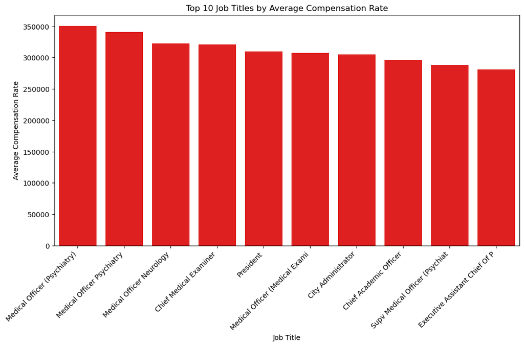

```python
top_job_comprate = df_clean.groupby("job_title")["comprate"].mean().sort_values(ascending=False).head(10)
plt.figure(figsize=(12, 6))
sns.barplot(x=top_job_comprate.index, y=top_job_comprate.values, color="red")
plt.title("Top 10 Job Titles by Average Compensation Rate")
plt.xlabel("Job Title")
plt.ylabel("Average Compensation Rate")
plt.xticks(rotation=45, ha="right")
plt.show()
```

This chart shows how compensation rate differs by job title. Higher-paying job titles may reflect specialized, senior, technical, or leadership roles within DC government.

### Visualization 5: Average Compensation Rate by Appointment Type

Intent: This visualization compares compensation rate across different appointment types.

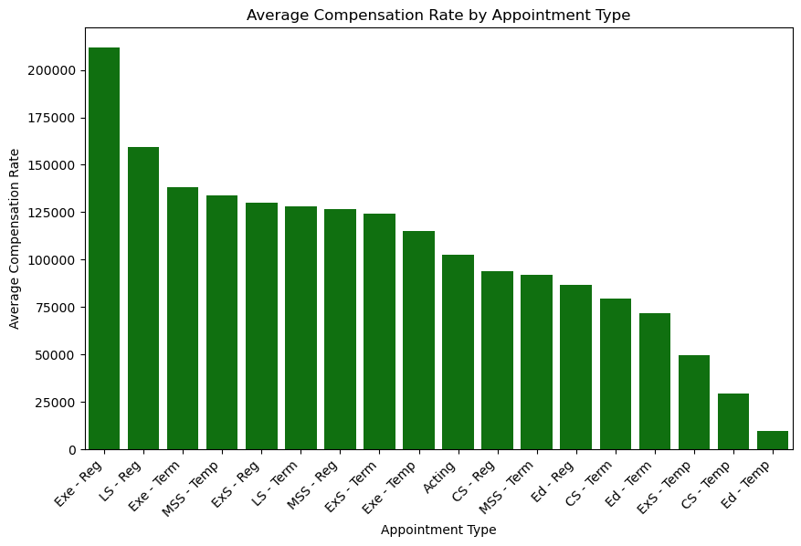

```python
appt_comprate = df_clean.groupby("appointment_type")["comprate"].mean().sort_values(ascending=False)

plt.figure(figsize=(10, 6))
sns.barplot(x=appt_comprate.index, y=appt_comprate.values, color="green")
plt.title("Average Compensation Rate by Appointment Type")
plt.xlabel("Appointment Type")
plt.ylabel("Average Compensation Rate")
plt.xticks(rotation=45, ha="right")
plt.show()
```

This chart shows whether compensation rate differs across appointment categories. If certain appointment types have higher average compensation rates, that may suggest differences in job security, role classification, or employee status.

### Visualization 6: Compensation Rate Spread Across Top Agencies

Intent: This boxplot shows compensation rate variation within the agencies that appear most often in the dataset.

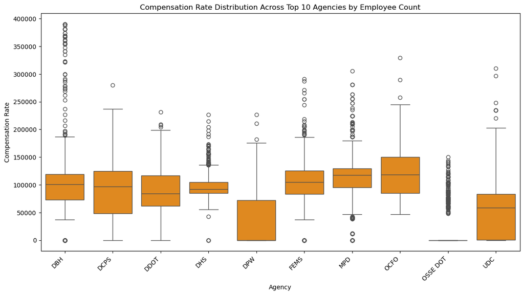

```python
top_10_agencies = df_clean["agency"].value_counts().head(10).index
top_agency_df = df_clean[df_clean["agency"].isin(top_10_agencies)]

plt.figure(figsize=(14, 7))
sns.boxplot(data=top_agency_df, x="agency", y="comprate", color="darkorange")
plt.title("Compensation Rate Distribution Across Top 10 Agencies by Employee Count")
plt.xlabel("Agency")
plt.ylabel("Compensation Rate")
plt.xticks(rotation=45, ha="right")
plt.show()
```

This boxplot shows the spread of compensation rates within major agencies. It helps reveal whether some agencies have wider compensation rates ranges, more outliers, or higher median compensation rates than others.

### Visualization 7: Average Compensation Rate by Hire Year

Intent: This visualization explores whether hire year is related to compensation rate patterns.

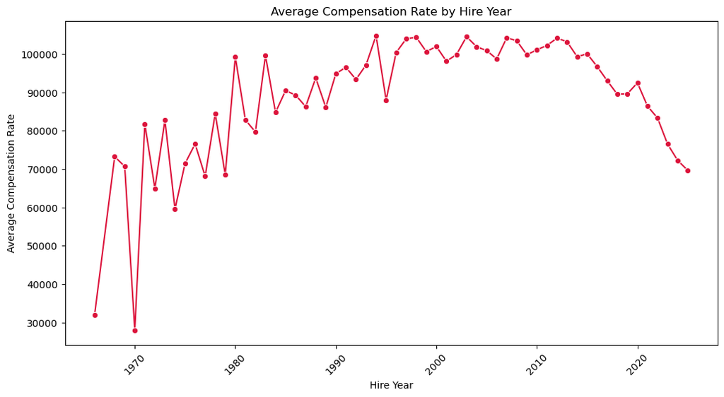

```python
comprate_by_year = df_clean.groupby("hire_year")["comprate"].mean().dropna()

plt.figure(figsize=(12, 6))
sns.lineplot(x=comprate_by_year.index, y=comprate_by_year.values, marker="o", color="crimson")
plt.title("Average Compensation Rate by Hire Year")
plt.xlabel("Hire Year")
plt.ylabel("Average Compensation Rate")
plt.xticks(rotation=45)
plt.show()
```

This line graph shows how average compensation rate varies by hire year. It can help identify whether employees hired in certain time periods tend to have higher or lower average compensation rates.

### Visualization 8: Compensation Rate by Years of Service

Intent: This scatterplot explores whether employees with more years of service tend to have higher compensation rates.

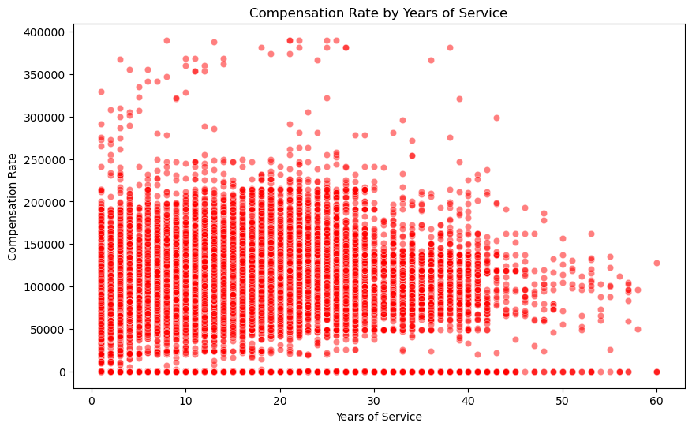

```python
#creates years of service based on hire date
current_year = 2026
df_clean["years_of_service"] = current_year - df_clean["hire_date"].dt.year
plt.figure(figsize=(10, 6))
sns.scatterplot(data=df_clean, x="years_of_service", y="comprate", alpha=0.5, color="red")
plt.title("Compensation Rate by Years of Service")
plt.xlabel("Years of Service")
plt.ylabel("Compensation Rate")
plt.show()
```

This scatterplot shows the relationship between years of service and compensation rate. If higher compensation rates appear more often among employees with more years of service, that may suggest that seniority plays some role in pay. However, if the points are widely spread out, then years of service alone does not fully explain differences in compensation rates.

### Visualization 9: Correlation Heatmap

Intent: This heatmap compares the relationships between numeric variables in the dataset.

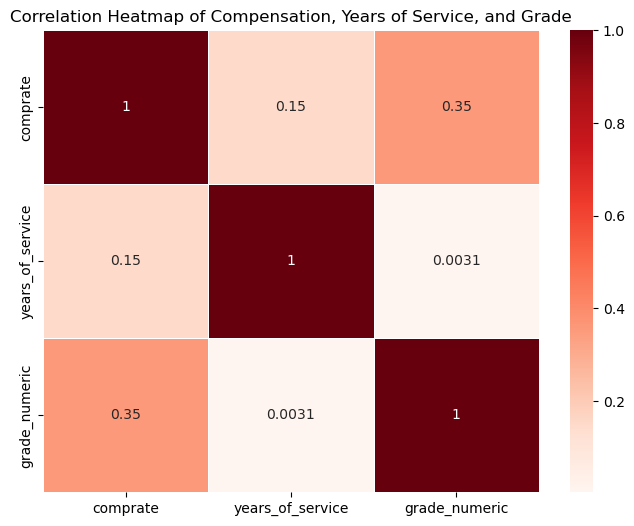

```python
#converts grade to numeric when possible
df_clean["grade_numeric"] = pd.to_numeric(df_clean["grade"], errors="coerce")
#selects numeric columns for the heatmap
numeric_cols = ["comprate", "years_of_service", "grade_numeric"]

#creates correlation matrix
corr_matrix = df_clean[numeric_cols].corr()

plt.figure(figsize=(8, 6))
sns.heatmap(corr_matrix, annot=True, cmap="Reds", linewidths=0.5)

plt.title("Correlation Heatmap of Compensation, Years of Service, and Grade")
plt.show()
```

This heatmap shows how strongly compensation rate, years of service, and grade relate to each other. Values closer to 1 indicate a stronger positive relationship, while values closer to 0 suggest a weaker relationship. This helps show whether compensation rate is more connected to grade, seniority, or neither.

### Visualization 10: Interactive Average Compensation Rate by Agency (Plotly)

Intent: This interactive bar chart lets the viewer hover over each agency to see exact average compensation rate and employee count which is a detail that static charts cannot provide.

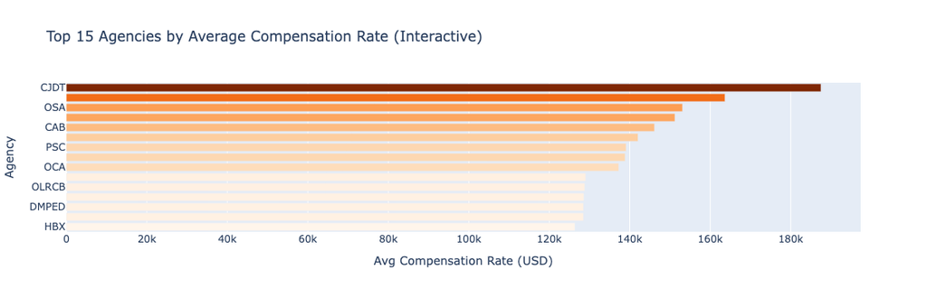

```python
#top 15 agencies by average comprate for a richer interactive view
top15_agency = df_clean.groupby("agency")["comprate"].agg(["mean", "count"]).reset_index()
top15_agency.columns = ["agency", "avg_comprate", "employee_count"]
top15_agency = top15_agency.sort_values("avg_comprate", ascending=False).head(15)
fig = px.bar(top15_agency, x="avg_comprate", y="agency",orientation="h", color="avg_comprate", color_continuous_scale="Oranges", hover_data={"employee_count": True, "avg_comprate": ":$,.0f"},labels={"avg_comprate": "Avg Compensation Rate (USD)", "agency": "Agency", "employee_count": "# Employees"},title="Top 15 Agencies by Average Compensation Rate (Interactive)")
fig.update_layout(yaxis={"categoryorder": "total ascending"}, coloraxis_showscale=False)
fig.show()
```

This interactive chart confirms that smaller, specialized agencies (CJDT, MOLC, OSA) have the highest average compensation rates, while large agencies like DCPS employ many more people at a lower average compensation rate. Hovering over each bar reveals the exact average compensation rate and employee count, showing the tradeoff between agency size and average compensation rate.

### Visualization 11: Interactive Compensation Rate Distribution by Appointment Type

Intent: This interactive box plot shows how compensation rates vary by appointment type. It helps compare the spread, middle values, and outliers, while also letting you hover over points to see details like job title.

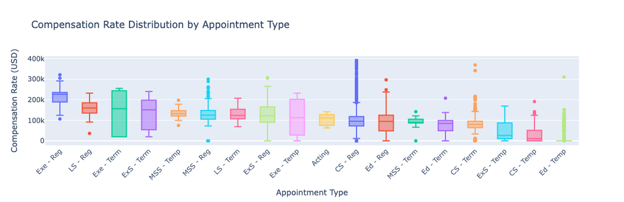

```python
#orders the appointment types by median comprate
appt_order = df_clean.groupby("appointment_type")["comprate"].median().sort_values(ascending=False).index.tolist()

fig2 = px.box(df_clean, x="appointment_type", y="comprate", color="appointment_type", category_orders={"appointment_type": appt_order},labels={"comprate": "Compensation Rate (USD)", "appointment_type": "Appointment Type"},title="Compensation Rate Distribution by Appointment Type",hover_data=["job_title", "agency"])
fig2.update_layout(showlegend=False, xaxis_tickangle=-45)
fig2.show()
```

### Visualization 12: Surprise Plot Compensation Rate Inequality Within Agencies

Intent: This plot compares the average compensation rate of the top 10% and bottom 10% of earners within each of the 10 largest agencies, revealing which agencies have the most extreme internal pay gaps which is an insight that average compensation rate alone conceals.

```python
#top 10% vs bottom 10% compensation rate gap by agency
top10_ag = df_clean["agency"].value_counts().head(10).index
agency_df = df_clean[df_clean["agency"].isin(top10_ag)]
```

```python
#calculates the average compensation rate for top and bottom 10% in each agency
def top10_mean(x):
    return x[x >= x.quantile(0.90)].mean()

def bot10_mean(x):
    return x[x <= x.quantile(0.10)].mean()
```

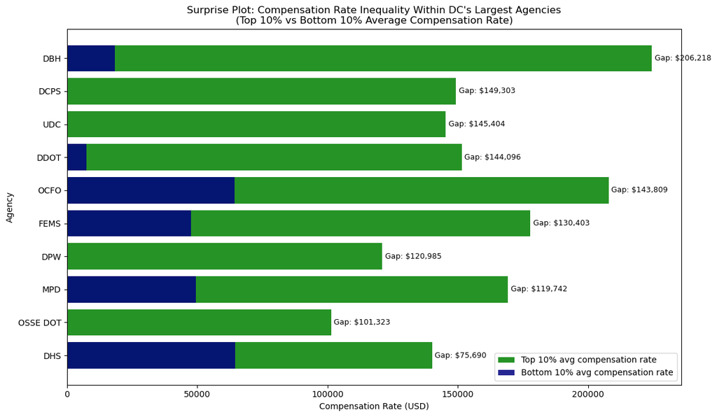

```python
gap_df = agency_df.groupby("agency")["comprate"].agg(top_10=top10_mean,bottom_10=bot10_mean).reset_index()
gap_df["gap"] = gap_df["top_10"] - gap_df["bottom_10"]
gap_df = gap_df.sort_values("gap", ascending=True)

fig, ax = plt.subplots(figsize=(12, 7))

ax.barh(gap_df["agency"], gap_df["top_10"], color="green", alpha=0.85, label="Top 10% avg compensation rate")
ax.barh(gap_df["agency"], gap_df["bottom_10"], color="navy", alpha=0.85, label="Bottom 10% avg compensation rate")

#annotates the gap
for i, (_, row) in enumerate(gap_df.iterrows()):
    ax.text(row["top_10"] + 1000, i, f'Gap: ${row["gap"]:,.0f}', va="center", fontsize=9, color="black")

ax.set_xlabel("Compensation Rate (USD)")
ax.set_ylabel("Agency")
ax.set_title("Surprise Plot: Compensation Rate Inequality Within DC's Largest Agencies\n(Top 10% vs Bottom 10% Average Compensation Rate)")
ax.legend()
plt.tight_layout()
plt.show()
```

This plot shows something that average compensation charts can easily miss: compensation rate differences within agencies vary across the dataset. Some agencies may have a moderate average compensation rate overall, but still show a large gap between their highest- and lowest-paid employees. This likely reflects the mix of positions within each agency, where senior specialists, managers, and entry-level employees may all be grouped under the same department. Because of this, agency alone does not fully explain compensation. The specific role or level of responsibility within the agency is just as important.

## Additional Analysis / Findings

### Additional Analysis 1: Compensation Rate Outliers

Motivation: I wanted to identify unusually high compensation rates because outliers can affect the average compensation rate and reveal specialized or senior-level roles.

```python
#identifies comp rate outliers using the IQR method
Q1 = df_clean["comprate"].quantile(0.25)
Q3 = df_clean["comprate"].quantile(0.75)
IQR = Q3 - Q1
upper_bound = Q3 + 1.5 * IQR

#defines comprate_outliers and employees above the upper bound
comprate_outliers = df_clean[df_clean["comprate"] > upper_bound]

print("Upper bound for compensation rate outliers:", upper_bound)
print("Number of compensation rate outliers:", comprate_outliers.shape[0])

comprate_outliers[["job_title", "agency", "comprate"]].sort_values(by="comprate", ascending=False).head(10)
```

```
Upper bound for compensation rate outliers: 200348.0
Number of compensation rate outliers: 428
```

|  | job_title | agency | comprate |
| --- | --- | --- | --- |
| 3034 | Medical Officer (Psychiatry) | DBH | 390232.0 |
| 1271 | Medical Officer (Psychiatry) | DBH | 390232.0 |
| 200 | Medical Officer (Psychiatry) | DBH | 390232.0 |
| 3229 | Medical Officer (Psychiatry) | DBH | 390232.0 |
| 3180 | Medical Officer (Psychiatry) | DBH | 390232.0 |
| 152 | Medical Officer (Psychiatry) | DBH | 390232.0 |
| 168 | Medical Officer Psychiatry | DBH | 387760.0 |
| 985 | Medical Officer (Psychiatry) | DBH | 381459.0 |
| 1522 | Medical Officer (Psychiatry) | DBH | 381459.0 |
| 656 | Medical Officer (Psychiatry) | DBH | 381459.0 |

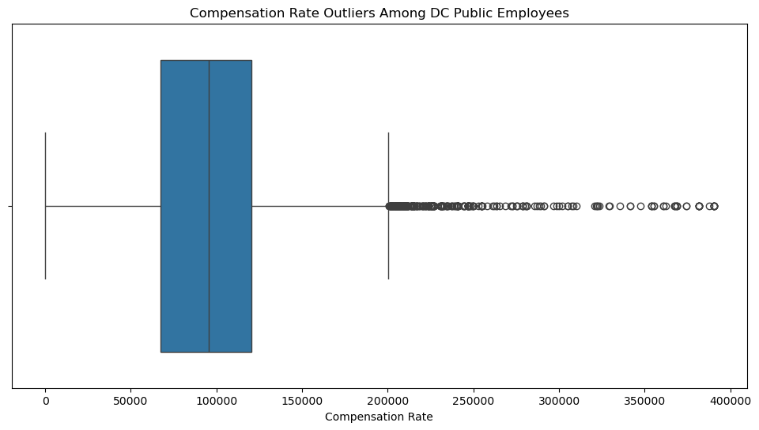

```python
plt.figure(figsize=(12, 6))
sns.boxplot(data=df_clean, x="comprate")
plt.title("Compensation Rate Outliers Among DC Public Employees")
plt.xlabel("Compensation Rate")
plt.show()
```

This boxplot shows the overall spread of compensation rates in the dataset, making it easy to identify where outliers fall relative to the bulk of employees.

### Additional Analysis 2: Compensation Rate Range Categories

Motivation: I wanted to group employees into compensation rate ranges to make the compensation rate distribution easier to interpret.

```python
#creates comprate range categories
df_clean["comprate_range"] = pd.cut(df_clean["comprate"], bins=[0, 50000, 75000, 100000, 125000, 150000, df_clean["comprate"].max()], labels=["Under 50K", "50K-75K", "75K-100K", "100K-125K", "125K-150K", "150K+"])
df_clean["comprate_range"].value_counts().sort_index()
```

```
comprate_range
Under 50K    5701
50K-75K      5156
75K-100K     7449
100K-125K    7795
125K-150K    4911
150K+        2551
Name: count, dtype: int64
```

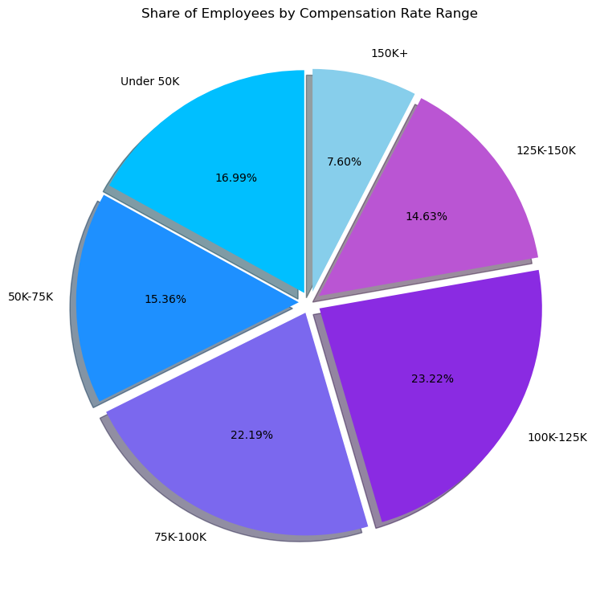

```python
comprate_range_counts = df_clean["comprate_range"].value_counts().sort_index()
colors =["deepskyblue", "dodgerblue", "mediumslateblue", "blueviolet", "mediumorchid", "skyblue"]
explode = [0.05] * len(comprate_range_counts)
plt.figure(figsize=(9, 9))
plt.pie(comprate_range_counts.values, labels=comprate_range_counts.index, autopct="%1.2f%%", startangle=90, colors=colors[:len(comprate_range_counts)], explode=explode, shadow=True)
plt.title("Share of Employees by Compensation Rate Range")
plt.show()
```

This pie chart shows the share of employees in each compensation rate range. It makes it easier to compare how much of the dataset falls into each compensation bracket. Larger slices represent compensation ranges with more employees, while smaller slices show less common compensation ranges.

## Insights and Conclusion

This project examined compensation rate patterns among DC public employees to understand which features appear most associated with higher compensation rates. The analysis suggests that compensation rate differences are connected to agency, job title, appointment type, and possibly hire year. Agencies and job titles showed especially clear differences in average compensation rate, which indicates that the type of work and department structure may play an important role in compensation.

The research question was answered by comparing compensation rates across several job-related features. The most significant patterns came from average compensation rate by agency, average compensation rate by job title, compensation rate distribution, and compensation rate outlier analysis. The visualizations showed that compensation rates are not evenly distributed, and some roles or agencies appear to be connected to much higher compensation rates than others.

One limitation of this analysis is that the dataset does not fully explain why compensation rate differences exist. It does not include every possible factor, such as education level, years of experience before government employment, performance history, or exact job responsibilities. Future analysis could combine this compensation rate data with more detailed employment classification data to better understand what drives public sector compensation.

```python
#exports the cleaned data
df_clean.to_csv("chiebuka_onwuka_final_project.csv", index=False)
```